# *Counterfeit Detection*

## *Scenario*

*Your IT consulting company offers a new mission to the Ministry of the Interior, as part of the fight against organized crime, the central office for the suppression of counterfeiting money. Your mission is to create a counterfeit detection algorithm.*

## Skills

- Descriptive statistics
- Automatic classification
- Interpret a PCA
- Logistic regression
- Clustering : Kmeans

**Mission 0 - Data Description**

- 1. Installing and loading packages
- 2. Loading data
- 2. Data Cleaning
- 3. Histograms
- 4. Analysis of the distribution of variables according to the is_genuine categorical variable
- 5. Correlation Matrix

**Mission 1 - Principal Component Analysis**

- 1. Some definitions
- 2. PCA

**Mission 2 - Classification**.

- 1. Hierarchical ascending classification
- 2. K-means algorithm
- 3. Conclusion

**Mission 3 - Modeling**

- 1. Preparation of cross-validation
- 2. Decision Tree
- 3. Logistic Regression
- 4. Prédiction

## Bibliography

- https://statistique-et-logiciel-r.com/nettoyer-et-valider-les-donnees-avec-r/
- http://www.sthda.com/english/wiki/creating-and-saving-graphs-r-base-graphs
- https://www.saturnscience.com/make-a-box-plot-with-single-column-data-using-ggplot2-tutorial/
- http://www.sthda.com/french/wiki/ggplot2-courbe-de-distribution-guide-de-demarrage-rapide-logiciel-r-et-visualisation-de-donnees
- https://www.math.ucla.edu/~anderson/rw1001/library/base/html/merge.html
- http://www.sthda.com/french/articles/38-methodes-des-composantes-principales-dans-r-guide-pratique/73-acp-analyse-en-composantes-principales-avec-r-l-essentiel/
- https://abcdr.thinkr.fr/comment-fixer-et-reproduire-laleatoire-set-seed/
- https://www.datanovia.com/en/lessons/k-means-clustering-in-r-algorith-and-practical-examples/
- https://openclassrooms.com/fr/courses/4297211-evaluez-et-ameliorez-les-performances-dun-modele-de-machine-learning/4308256-evaluez-un-algorithme-de-classification-qui-retourne-des-valeurs-binaires
- https://www.lri.fr/~antoine/Courses/Master-ISI/Tr-evaluation-M-ISIx4.pdf
- https://www.analytics-tuts.com/how-to-split-train-and-test-data-in-r/
- https://www.miskatonic.org/2012/09/24/counting-and-aggregating-in-r/
- https://stackoverflow.com/questions/35907477/caret-package-stratified-cross-validation-in-train-function
- https://stackoverflow.com/questions/8120984/scaling-data-in-r-ignoring-specific-columns
- https://r-forge.r-project.org/scm/viewvc.php/RegressionTests/Code/glmStepAIC.R?view=markup&root=caret
- https://rstudio-pubs-static.s3.amazonaws.com/353795_fd9aa892e58841118b7f326efb1db113.html
- https://stackoverflow.com/questions/24131798/using-caret-package-but-getting-error-in-librarye1071
- https://stats.stackexchange.com/questions/52274/how-to-choose-a-predictive-model-after-k-fold-cross-validation
- https://machinelearningmastery.com/train-final-machine-learning-model/
- https://www.researchgate.net/post/What_is_the_relation_between_root_mean_square_error_and_accuracy_of_a_classifier_like_SVM_ANN
- http://dataaspirant.com/2017/02/03/decision-tree-classifier-implementation-in-r/

## Mission 0 - Data Description

## 1. Installing and loading packages

```r
library("forecast")
library("reshape")
library("ggplot2")
library("ggpubr")
library("FactoMineR")
library("factoextra")
library("dendextend")
library("plyr")
library("dplyr")
library("corrplot")
library("rpart")
library("rpart.plot")

# Logistic regression
library("tidyverse")
library("caret")
library("leaps")
library("MASS")
```

```r
# multiplot : Plot multiple graphics

multiplot <- function(..., plotlist=NULL, file, cols=1, layout=NULL) {
  library(grid)

  # Make a list from the ... arguments and plotlist
  plots <- c(list(...), plotlist)

  numPlots = length(plots)

  # If layout is NULL, then use 'cols' to determine layout
  if (is.null(layout)) {
    # Make the panel
    # ncol: Number of columns of plots
    # nrow: Number of rows needed, calculated from # of cols
    layout <- matrix(seq(1, cols * ceiling(numPlots/cols)),
                    ncol = cols, nrow = ceiling(numPlots/cols))
  }

 if (numPlots==1) {
    print(plots[[1]])

  } else {
    # Set up the page
    grid.newpage()
    pushViewport(viewport(layout = grid.layout(nrow(layout), ncol(layout))))

    # Make each plot, in the correct location
    for (i in 1:numPlots) {
      # Get the i,j matrix positions of the regions that contain this subplot
      matchidx <- as.data.frame(which(layout == i, arr.ind = TRUE))

      print(plots[[i]], vp = viewport(layout.pos.row = matchidx$row,
                                      layout.pos.col = matchidx$col))
    }
  }
}
```

## 2. Loading data

```r
bills <- read.csv("data/billets.csv", header=TRUE, sep=",",na.strings=c(""))
bills_to_predict <- read.csv("data/example.csv", header=TRUE, sep=",",na.strings=c(""))
head(bills)
```

| is_genuine | diagonal | height_left | height_right | margin_low | margin_up | length |
| --- | --- | --- | --- | --- | --- | --- |
| True | 171.81 | 104.86 | 104.95 | 4.52 | 2.89 | 112.83 |
| True | 171.67 | 103.74 | 103.70 | 4.01 | 2.87 | 113.29 |
| True | 171.83 | 103.76 | 103.76 | 4.40 | 2.88 | 113.84 |
| True | 171.80 | 103.78 | 103.65 | 3.73 | 3.12 | 113.63 |
| True | 172.05 | 103.70 | 103.75 | 5.04 | 2.27 | 113.55 |
| True | 172.57 | 104.65 | 104.44 | 4.54 | 2.99 | 113.16 |

```r
fake_bills <- subset(bills, is_genuine == 'False')
real_bills <- subset(bills, is_genuine == 'True')
cat(dim(fake_bills)[1],"are fake bills.\n")
cat(dim(real_bills)[1],"are real bills.")
```

```
70 are fake bills.
100 are real bills.
```

## 3. Data Cleaning

We work with real data: we must take into account the fact that some data may be missing, outliers or atypical. We must clean our dataset before our analyzes.

### Data structure

```r
str(bills)
```

```
'data.frame':	170 obs. of  7 variables:
 $ is_genuine  : Factor w/ 2 levels "False","True": 2 2 2 2 2 2 2 2 2 2 ...
 $ diagonal    : num  172 172 172 172 172 ...
 $ height_left : num  105 104 104 104 104 ...
 $ height_right: num  105 104 104 104 104 ...
 $ margin_low  : num  4.52 4.01 4.4 3.73 5.04 4.54 3.97 3.54 4.06 4.63 ...
 $ margin_up   : num  2.89 2.87 2.88 3.12 2.27 2.99 2.9 3.19 3.33 3.02 ...
 $ length      : num  113 113 114 114 114 ...
```

- The categorical variable **is_genuine** is of class 'factor'.
- All the other columns represent the dimensions of the ticket: they are in digital format.
- There are 170 observations for 7 variables.

### Are there any missing data?

```r
sapply(bills, function(x) sum(is.na(x)))
```

**is_genuine**

0

**diagonal**

0

**height_left**

0

**height_right**

0

**margin_low**

0

**margin_up**

0

**length**

0

There is no missing data.

### Outliers and unusual data

```r
summary(bills)
```

```
 is_genuine     diagonal      height_left     height_right     margin_low
 False: 70   Min.   :171.0   Min.   :103.2   Min.   :103.1   Min.   :3.540
 True :100   1st Qu.:171.7   1st Qu.:103.8   1st Qu.:103.7   1st Qu.:4.050
             Median :171.9   Median :104.1   Median :104.0   Median :4.450
             Mean   :171.9   Mean   :104.1   Mean   :103.9   Mean   :4.612
             3rd Qu.:172.1   3rd Qu.:104.3   3rd Qu.:104.2   3rd Qu.:5.128
             Max.   :173.0   Max.   :104.9   Max.   :105.0   Max.   :6.280
   margin_up         length
 Min.   :2.270   Min.   :110.0
 1st Qu.:3.013   1st Qu.:111.9
 Median :3.170   Median :112.8
 Mean   :3.170   Mean   :112.6
 3rd Qu.:3.330   3rd Qu.:113.3
 Max.   :3.680   Max.   :114.0
```

**pdf:** 2

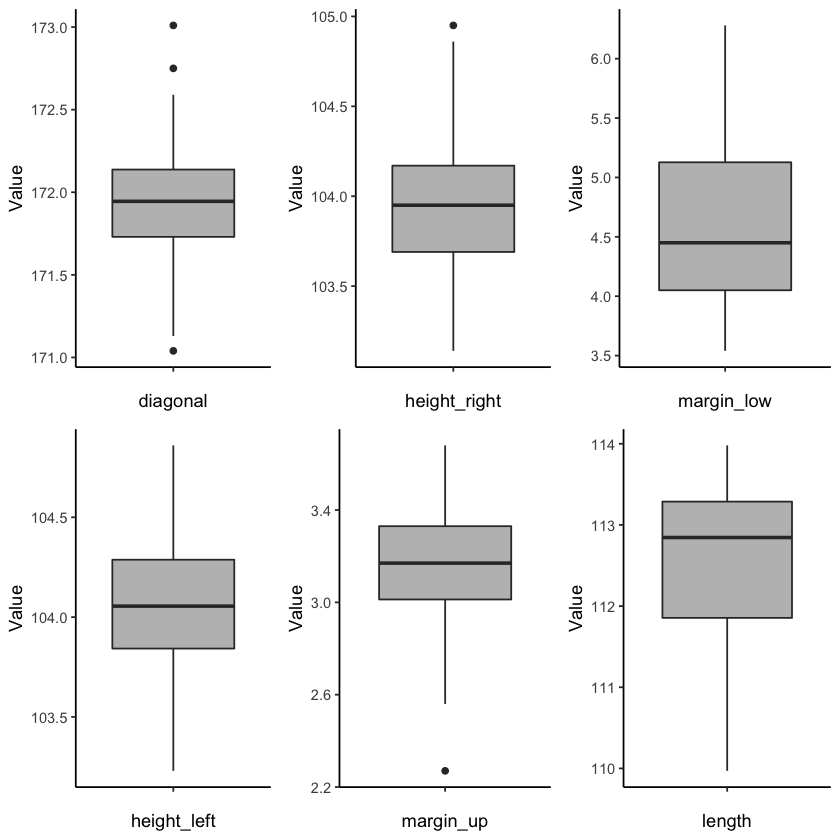

```r
b1 <- ggplot(bills, aes(x="", y=diagonal)) + geom_boxplot(fill="gray")+ labs(x="diagonal", y = "Value")+ theme_classic()
b2 <- ggplot(bills, aes(x="", y=height_left)) + geom_boxplot(fill="gray")+ labs(x="height_left", y = "Value")+ theme_classic()
b3 <- ggplot(bills, aes(x="", y=height_right)) + geom_boxplot(fill="gray")+ labs(x="height_right", y = "Value")+ theme_classic()
b4 <- ggplot(bills, aes(x="", y=margin_up)) + geom_boxplot(fill="gray")+ labs(x="margin_up", y = "Value")+ theme_classic()
b5 <- ggplot(bills, aes(x="", y=margin_low)) + geom_boxplot(fill="gray")+ labs(x="margin_low", y = "Value")+ theme_classic()
b6 <- ggplot(bills, aes(x="", y=length)) + geom_boxplot(fill="gray")+ labs(x="length", y = "Value")+ theme_classic()

# Save : Figure
png("figure/Figure 1 - Analysis of the values taken by the variables.png", width = 16, height = 9, units = 'in', res = 300)
multiplot(b1,b2,b3,b4,b5,b6, cols=3)
dev.off()

# Plotting : Figure
multiplot(b1,b2,b3,b4,b5,b6, cols=3)
```

Paying attention to the min and max values, we deduce that there is no outlier or atypical value. The fact that there are some (weak) outliers is possible in the context of the mission. In addition to that, we note that values are very large compared to others: it will have to standardize the data so that the big values take no precedence over small.

### Categorical variable

```r
levels(bills$is_genuine)
```

1. 'False'

2. 'True'

There are two categories of tickets: real and fake.

## 4. Analysis of the distribution of variables according to the is_genuine categorical variable

**pdf:** 2

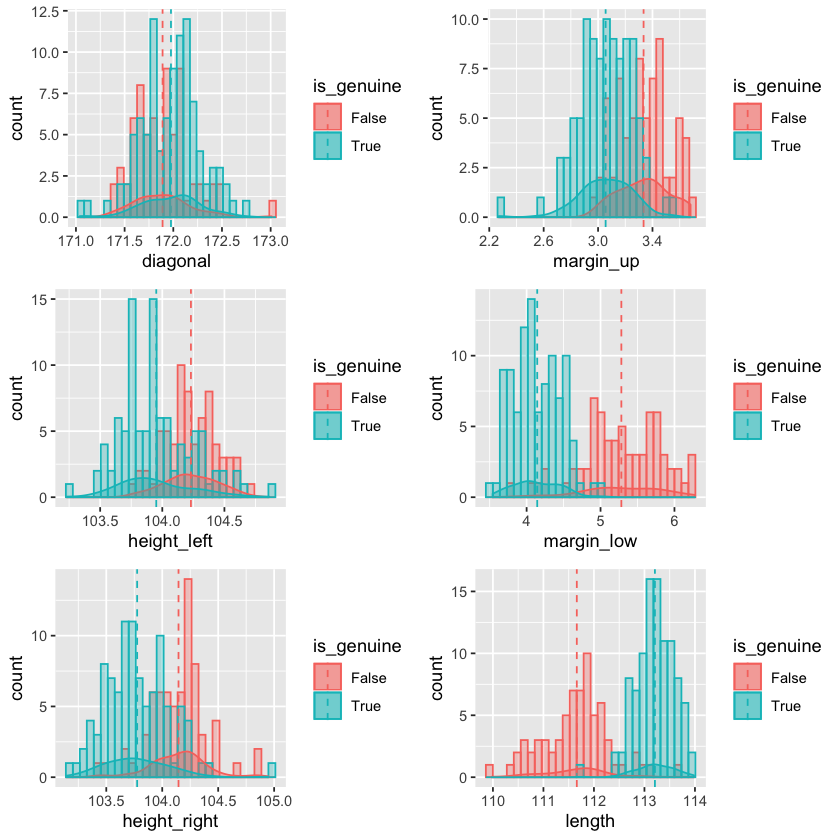

```r
# Calculation of average variables and by category true or false ticket
mu_diagonal <- ddply(bills, "is_genuine", summarise, grp.mean=mean(diagonal))
mu_height_left <- ddply(bills, "is_genuine", summarise, grp.mean=mean(height_left))
mu_height_right <- ddply(bills, "is_genuine", summarise, grp.mean=mean(height_right))
mu_margin_up <- ddply(bills, "is_genuine", summarise, grp.mean=mean(margin_up))
mu_margin_low <- ddply(bills, "is_genuine", summarise, grp.mean=mean(margin_low))
mu_length <- ddply(bills, "is_genuine", summarise, grp.mean=mean(length))

p1 <- ggplot(bills, aes(x=diagonal, fill=is_genuine, color=is_genuine)) + geom_histogram(position="identity", alpha=0.3, bins=30) + geom_vline(data=mu_diagonal, aes(xintercept=grp.mean, color=is_genuine),linetype="dashed") + geom_density(alpha=0.4)
p2 <- ggplot(bills, aes(x=height_left, fill=is_genuine, color=is_genuine)) + geom_histogram(position="identity", alpha=0.3, bins=30) + geom_vline(data=mu_height_left, aes(xintercept=grp.mean, color=is_genuine),linetype="dashed") + geom_density(alpha=0.4)
p3 <- ggplot(bills, aes(x=height_right, fill=is_genuine, color=is_genuine)) + geom_histogram(position="identity", alpha=0.3, bins=30) + geom_vline(data=mu_height_right, aes(xintercept=grp.mean, color=is_genuine),linetype="dashed") + geom_density(alpha=0.4)
p4 <- ggplot(bills, aes(x=margin_up, fill=is_genuine, color=is_genuine)) + geom_histogram(position="identity", alpha=0.3, bins=30) + geom_vline(data=mu_margin_up, aes(xintercept=grp.mean, color=is_genuine),linetype="dashed") + geom_density(alpha=0.4)
p5 <- ggplot(bills, aes(x=margin_low, fill=is_genuine, color=is_genuine)) + geom_histogram(position="identity", alpha=0.3, bins=30) + geom_vline(data=mu_margin_low, aes(xintercept=grp.mean, color=is_genuine),linetype="dashed") + geom_density(alpha=0.4)
p6 <- ggplot(bills, aes(x=length, fill=is_genuine, color=is_genuine)) + geom_histogram(position="identity", alpha=0.3, bins=30) + geom_vline(data=mu_length, aes(xintercept=grp.mean, color=is_genuine),linetype="dashed") + geom_density(alpha=0.4)

# Save : Figure
png("figure/Figure 2 - Variable Analysis.png", width = 16, height = 9, units = 'in', res = 300)
multiplot(p1,p2,p3,p4,p5,p6, cols=2)
dev.off()

# Plotting : Figure
multiplot(p1,p2,p3,p4,p5,p6, cols=2)
```

- Observations :
- In both cases: the diagonal, height_left, height_right, margin_up values are approximately distributed in the same range or the False interval is included in the True range.
- For margin_low: the interval of the real bills is included in [3.5 - 5] while that of the counterfeit bills is included in [4 - 6.5].
- For length: the interval of the real notes is included in [112 - 114] while that of the counterfeit bills is included in [110 - 114].
- It would seem, then, that what distinguishes the true from the counterfeit bills is that:
- The top margin of the bills
- The lower margin of the bills
- The length of the bills

## 5. Correlation Matrix

To observe the possible correlations between varibales, the correlation matrix between the variables is represented.

**pdf:** 2

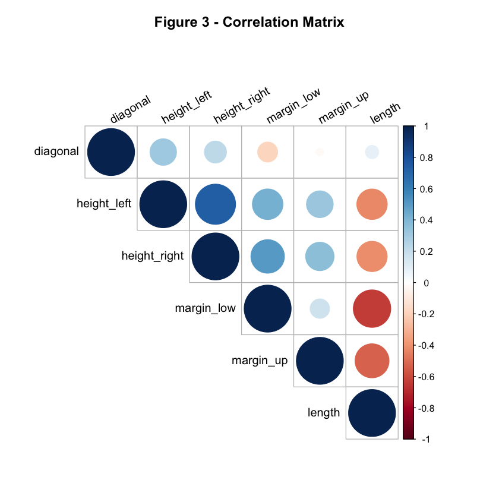

```r
mcor <- cor(bills[,c(2:7)])

# Save : Figure
png("figure/Figure 3 - Correlation Matrix.png", width = 10, height = 9, units = 'in', res = 300)
corrplot(mcor, type="upper", tl.col="black", tl.srt=30, title="Figure 3 - Correlation Matrix", mar=c(0,0,3,0))
dev.off()

# Plotting : Figure
corrplot(mcor, type="upper", tl.col="black", tl.srt=30, title="Figure 3 - Correlation Matrix", mar=c(0,0,3,0))
```

## Mission 1 - Principal Component Analysis

```r
#data <- merge(billets, billets_a_predire, all = T, sort = FALSE)
cat('The number of active individuals for PCA is',dim(bills)[1],'.\n')
cat('The number of additional individuals for PCA is',dim(bills_to_predict)[1],'.')
```

```
The number of active individuals for PCA is 170 .
The number of additional individuals for PCA is 5 .
```

### 1. Some definitions

[figure not shown]

## 2. PCA

```r
res.pca <- PCA(bills, quali.sup = 1, scale.unit = TRUE, graph=FALSE)
```

### Scree Plot Eigenvalues : Percentage of variances explained by each principal axis

**null device:** 1

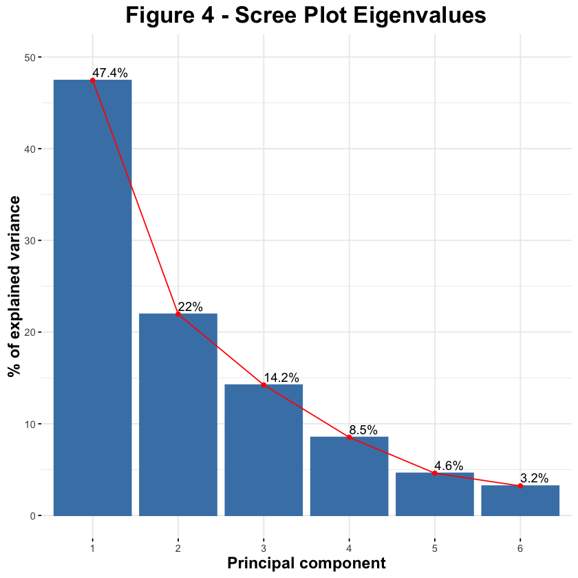

```r
eig.val <- get_eigenvalue(res.pca)
figure6 <- fviz_screeplot(res.pca,addlabels=TRUE,ylim=c(0,50),linecolor='red') + labs(title = "Figure 4 - Scree Plot Eigenvalues", x = "Principal component", y = "% of explained variance") + theme(plot.title = element_text(size=20, face="bold",hjust = 0.5),axis.title.x = element_text(color="black", size=14, face="bold",hjust = 0.5),axis.title.y = element_text(color="black", size=14, face="bold",vjust = 0.5))+ ggsave("figure/figure4_scree_plot.png", width = 16, height = 9)
plot(figure6)
dev.off()
```

### Quality of representation of the variables on the factorial axes

**pdf:** 2

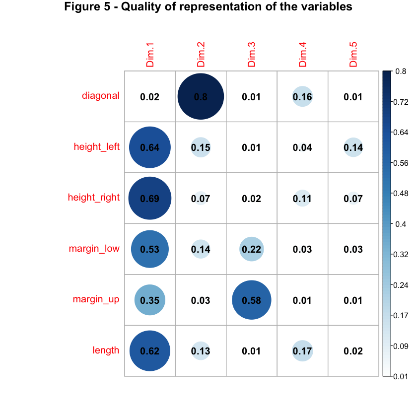

```r
# Save : Figure
var <- get_pca_var(res.pca)
png("figure/Figure 5 - Quality of representation of the variables.png", width = 8, height = 9, units = 'in', res = 300)
corrplot(var$cos2, is.corr=FALSE,addCoef.col = "black", title="Figure 5 - Quality of representation of the variables", mar=c(0,0,1,0))
dev.off()

# Plot : Figure
corrplot(var$cos2, is.corr=FALSE,addCoef.col = "black", title="Figure 5 - Quality of representation of the variables", mar=c(0,0,1,0))
```

**pdf:** 2

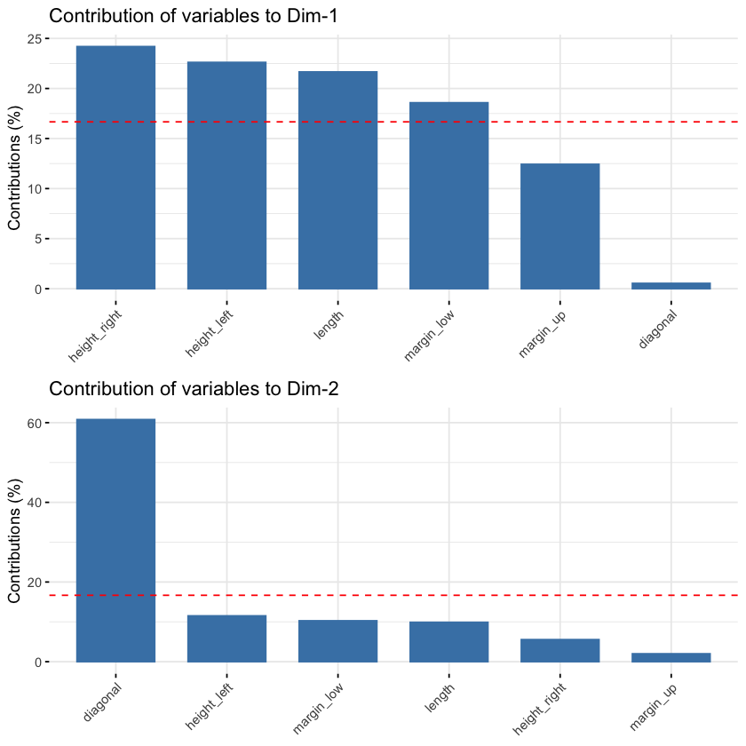

```r
# Contributions of variables to PC1
contrib1 <- fviz_contrib(res.pca, choice = "var", axes = 1, top = 6)
# Contributions of variables to PC2
contrib2 <- fviz_contrib(res.pca, choice = "var", axes = 2, top = 6)

# Save : Figure
png("figure/Figure 6 - Variables Contribution.png", width = 8, height = 9, units = 'in', res = 300)
multiplot(contrib1,contrib2, cols=1)
dev.off()

# Plot : Figure
multiplot(contrib1,contrib2, cols=1)
```

### Correlation Circle

**null device:** 1

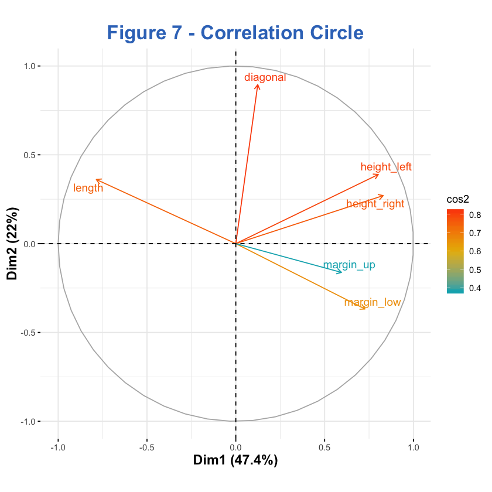

```r
# Colorer en fonction du cos2: qualité de représentation
figure7 <- fviz_pca_var(res.pca, col.var = "cos2",gradient.cols = c("#00AFBB", "#E7B800", "#FC4E07"),repel = TRUE) + labs(title = "Figure 7 - Correlation Circle") + theme(plot.title = element_text(color="#3876C2", size=20, face="bold",hjust = 0.5),axis.title.x = element_text(color="black", size=14, face="bold",hjust = 0.5),axis.title.y = element_text(color="black", size=14, face="bold",vjust = 0.5)) + ggsave("figure/figure7_correlation_circle.png", width = 16, height = 9)
plot(figure7)
dev.off()
```

The correlation graph of the variables shows the relationships between all the variables and the factorial axes. It can be interpreted as follows:

- The **positively correlated variables** are grouped:
- height_left and height_right
- margin_low and margin_up
- The **negatively correlated variables** are positioned on the opposite sides of the graph origin (opposite quadrants):
- length compared to others
- The distance between the variables and the origin measures the **quality of representation** of the variables. Variables that are far from the origin are well represented by the ACP (red / orange color). All the variables (slightly less for margin_up: blue color) are well explained by the first two main components (Dim.1 & Dim.2) because they are positioned close to the correlation circle.
- Axis 1 represents the vertical and horizontal dimensions of the bill : + a bill is on the right, + its vertical dimensions are large and - its horizontal dimensions are high.
- Axis 2 represents the diagonal of the note. : + a bill is up, + its diagonal is high

We find the observations on the first factorial axis: the correlated variables (close to the first factorial axis) are grouped in the same direction:

### Representation of individuals

**null device:** 1

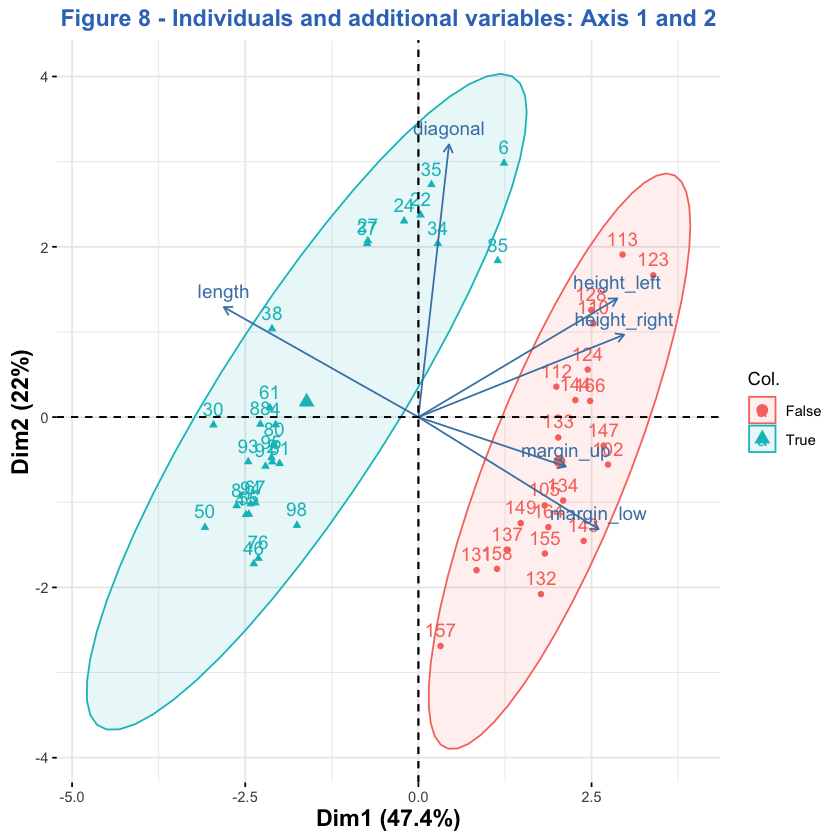

```r
figure10a <- fviz_pca_biplot(res.pca, select.ind = list(cos2 = 0.8, contrib=50),axes = c(1,2), addEllipses =TRUE, col.ind = bills$is_genuine ,color_palette=c("#00AFBB","#FC4E07")) + labs(title = "Figure 8 - Individuals and additional variables: Axis 1 and 2") + theme(plot.title = element_text(color="#3876C2", size=14, face="bold",hjust = 0.5),axis.title.x = element_text(color="black", size=14, face="bold",hjust = 0.5),axis.title.y = element_text(color="black", size=14, face="bold",vjust = 0.5)) + ggsave("figure/figure8_Individuals_additional_variables.png", width = 16, height = 9)
plot(figure10a)
dev.off()
```

The projection of the 50 individuals who contribute the most to the formation of the first factorial plane and having a quality of representation cos2 greater than 0.8 separates very well the two categories of bills. We note that the reality of a bills is directed only on one axis: the one led by lenght and margin_low.

- The "true" criterion of a bill is characterized by a good value of length.
- The "false" criterion of a bill is characterized by a high value for margin_low.

In this part, by using a principal component analysis, we were able to confirm our initial hypothesis. The variables that contribute the most to the categorization of the bills are the length of the bill, its lower margin and its higher margin. In the next part, we will apply classification methods to group geometrically similar notes.

## Mission 2 - Classification

## 1. Hierarchical ascending classification

### Realization of hierarchical ascending classification

```
groups.hc
 1  2
71 99
```

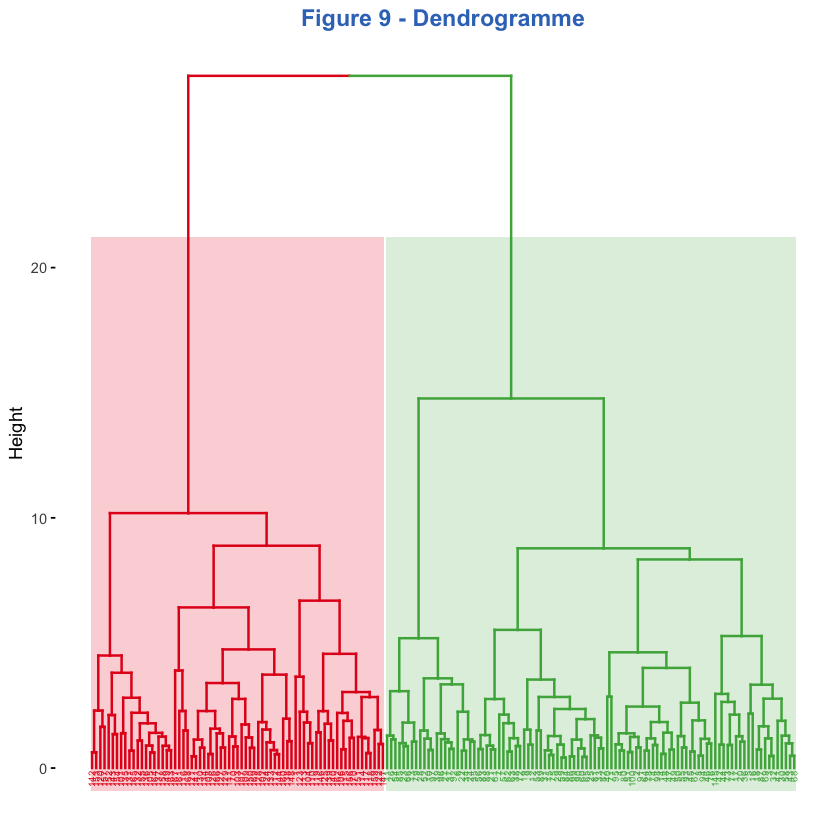

```r
# data_scaled : centering data reduction: to avoid variables with high variance weighing on the results
data_scaled <- scale(bills[,c(2:7)])

# d : distance matrix: criterion of resemblance between individuals
d <- dist(data_scaled, method = "euclidean")

# hc - Ward's criterion: criterion of resemblance between groups of individuals
data.hc <- hclust(d, method = "ward.D2" )

# Clustering
groups.hc <- cutree(data.hc, k = 2)

# Number of members in each cluster
table(groups.hc)

# Display of the dendrogram

figure11 <- fviz_dend(data.hc, k = 2,
          cex = 0.4,                      # Label size
          palette = "Set1",               # Color palette see ?ggpubr::ggpar
          rect = TRUE, rect_fill = TRUE,  # Add rectangle around groups
          rect_border = "Set1",           # Rectangle color
          labels_track_height = 0.4       # Augment the room for labels
          ) + labs(title="Figure 9 - Dendrogramme") +theme(plot.title = element_text(color="#3876C2", size=14, face="bold",hjust = 0.5)) + ggsave("figure/figure9_dendrogramme.png", width = 8, height = 9)

plot(figure11)
```

```r
bills.hc <- data.frame(bills,groups.hc)
head(bills.hc)
```

| is_genuine | diagonal | height_left | height_right | margin_low | margin_up | length | groups.hc |
| --- | --- | --- | --- | --- | --- | --- | --- |
| True | 171.81 | 104.86 | 104.95 | 4.52 | 2.89 | 112.83 | 1 |
| True | 171.67 | 103.74 | 103.70 | 4.01 | 2.87 | 113.29 | 2 |
| True | 171.83 | 103.76 | 103.76 | 4.40 | 2.88 | 113.84 | 2 |
| True | 171.80 | 103.78 | 103.65 | 3.73 | 3.12 | 113.63 | 2 |
| True | 172.05 | 103.70 | 103.75 | 5.04 | 2.27 | 113.55 | 2 |
| True | 172.57 | 104.65 | 104.44 | 4.54 | 2.99 | 113.16 | 2 |

### Cluster representation of the hierarchical ascending classification

**null device:** 1

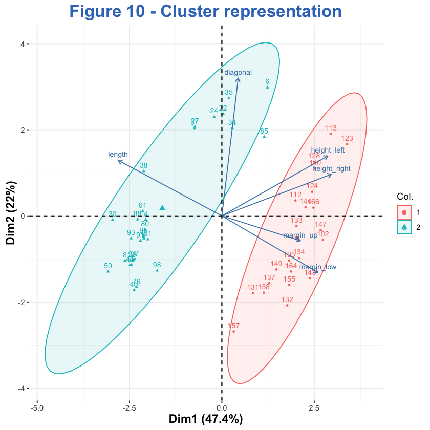

```r
bills.hc <- transform(bills.hc, groups.hc = as.factor(groups.hc))
figure12 <- fviz_pca_biplot(res.pca, pointsize = 1, labelsize = 3,axes = c(1,2),select.ind = list(cos2 = 0.8, contrib=50),addEllipses = TRUE,col.ind = bills.hc$groups.hc, color_palette=c("#00AFBB", "#E7B800")) + labs(title = "Figure 10 - Cluster representation") + theme(plot.title = element_text(color="#3876C2", size=20, face="bold",hjust = 0.5),axis.title.x = element_text(color="black", size=14, face="bold",hjust = 0.5),axis.title.y = element_text(color="black", size=14, face="bold",vjust = 0.5)) + ggsave("figure/figure10_clusters.png", width = 16, height = 9)
plot(figure12)
dev.off()
```

In the factorial plane, the same separation as that seen with PCA is obtained, which at first glance seems very suitable.

### Classification performance

```r
bills.hc <- transform(bills.hc, groups.hc = as.numeric(groups.hc))

# Cluster 1 : counterfeit bills.
bills.hc$groups.hc[bills.hc$groups.hc=='1']<-'False'

# Cluster 2 : real bills.
bills.hc$groups.hc[bills.hc$groups.hc=='2']<-'True'
bills.hc <- transform(bills.hc, groups.hc = as.factor(groups.hc))

# Confusion matrix : Real data and data predicted by the ACH
matrix_confusion_hc = table(bills.hc$is_genuine,bills.hc$groups.hc)
matrix_confusion_hc
```

```
        False True
  False    69    1
  True      2   98
```

The confusion matrix reads as follows:

```r
# fake - real : Bill
# negative - positive : Prediction

# error_1_hc : Type I error: False positives: The worst mistake is to designate a fake ticket as a real ticket.
error_1_hc = matrix_confusion_hc[1,2]/(matrix_confusion_hc[1,2]+matrix_confusion_hc[1,1])

# error_2_hc : Type II Error: False Negatives: The second mistake is to designate a real ticket as a fake ticket.
error_2_hc <- matrix_confusion_hc[2,1]/(matrix_confusion_hc[2,1]+matrix_confusion_hc[2,2])
cat('Type I error:', round(100*error_1_hc,2),'%\n')
cat('Type II error:', round(100*error_2_hc,2),'%')
```

```
Type I error: 1.43 %
Type II error: 2 %
```

## 2. K-means algorithm

### Realization of the k-means algorithm

```r
# The k-means algorithm starts with k centroids randomly chosen.
# To use random processes while making them reproducible
# in time or on another machine / system, we use the set.seed () function
set.seed(123)

# Algorithme des k-means avec k=2
km.res <- kmeans(scale(bills[,c(2:7)]), centers = 2, iter.max = 1000, nstart = 100)

# Coordonnées des centroides
centroides <- aggregate(bills, by=list(cluster=km.res$cluster), mean)
centroides
```

| cluster | is_genuine | diagonal | height_left | height_right | margin_low | margin_up | length |
| --- | --- | --- | --- | --- | --- | --- | --- |
| 1 | NA | 171.9568 | 103.9072 | 103.7312 | 4.139247 | 3.045054 | 113.2403 |
| 2 | NA | 171.9210 | 104.2586 | 104.1660 | 5.183247 | 3.321818 | 111.7613 |

```r
# bills_cluster : Adding clusters for each
bills.km <- cbind(bills, cluster = km.res$cluster)
head(bills.km)
```

| is_genuine | diagonal | height_left | height_right | margin_low | margin_up | length | cluster |
| --- | --- | --- | --- | --- | --- | --- | --- |
| True | 171.81 | 104.86 | 104.95 | 4.52 | 2.89 | 112.83 | 2 |
| True | 171.67 | 103.74 | 103.70 | 4.01 | 2.87 | 113.29 | 1 |
| True | 171.83 | 103.76 | 103.76 | 4.40 | 2.88 | 113.84 | 1 |
| True | 171.80 | 103.78 | 103.65 | 3.73 | 3.12 | 113.63 | 1 |
| True | 172.05 | 103.70 | 103.75 | 5.04 | 2.27 | 113.55 | 1 |
| True | 172.57 | 104.65 | 104.44 | 4.54 | 2.99 | 113.16 | 2 |

### Representation of clusters determined with the k-means algorithm

**null device:** 1

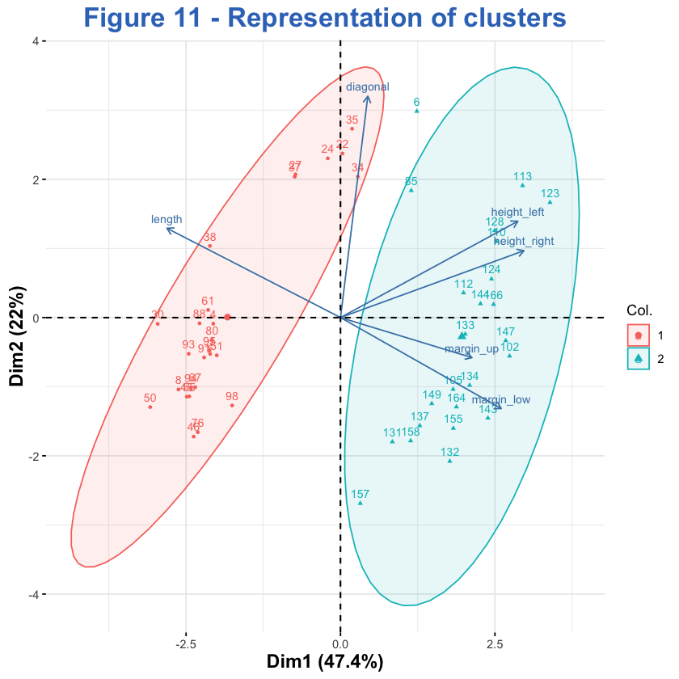

```r
bills.km <- transform(bills.km, cluster = as.factor(cluster))
figure13 <- fviz_pca_biplot(res.pca, pointsize = 1, labelsize = 3, axes = c(1,2),select.ind = list(cos2 = 0.8, contrib=50),addEllipses = TRUE,col.ind = bills.km$cluster, color_palette=c("#00AFBB", "#E7B800"))+ labs(title = "Figure 11 - Representation of clusters") + theme(plot.title = element_text(color="#3876C2", size=20, face="bold",hjust = 0.5),axis.title.x = element_text(color="black", size=14, face="bold",hjust = 0.5),axis.title.y = element_text(color="black", size=14, face="bold",vjust = 0.5)) + ggsave("figure/figure11_clusters.png", width = 16, height = 9)
plot(figure13)
dev.off()
```

### Classification performance

```r
bills.km <- transform(bills.km, cluster = as.integer(cluster))
# Cluster 1 : counterfeit bills.
bills.km$cluster[bills.km$cluster==1]<-'True'

# Cluster 2 : real bills.
bills.km$cluster[bills.km$cluster==2]<-'False'
bills.km <- transform(bills.km, cluster = as.factor(cluster))

# Matrix confusion : from real data and data predicted by the k-means algorithm.
matrix_confusion_km = table(bills.km$is_genuine,bills.km$cluster)
matrix_confusion_km
```

```
        False True
  False    69    1
  True      8   92
```

```r
# fake - real : Bill
# negative - positive : Prediction

# error_1_km : Type I error: False positives: The worst mistake is to designate a fake ticket as a real ticket.
error_1_km = matrix_confusion_km[1,2]/(matrix_confusion_km[1,2]+matrix_confusion_km[1,1])

# error_2_km : Type II Error: False Negatives: The second mistake is to designate a real ticket as a fake ticket.
error_2_km <- matrix_confusion_km[2,1]/(matrix_confusion_km[2,1]+matrix_confusion_km[2,2])
cat('Type I error:', round(100*error_1_km,2),'%\n')
cat('Type II error:', round(100*error_2_km,2),'%')
```

```
Type I error: 1.43 %
Type II error: 8 %
```

## 3. Conclusion

The hierarchical ascending classification is therefore more efficient than the k-means algorithm.

Now we have seen how to categorize our notes based on their geometric data, either using a hierarchical ascending classification, or with the k-means algorithm, we can move on to modeling data as well as to predictions.

## Mission 3 - Modelisation

Two models will be evaluated by cross-validation: decision tree and logistic regression .

- Cross validation is performed with 5 folds, 5 parts stratified with respect to the class of the note.
- At each iteration, 4 parts will be used to train the dataset. And a part will be used to calculate a performance indicator: the RSME mean squared error. This is a total distance between the actual classes and the values taken by the model made on the training game.
- At the end of the 5 iterations of cross-validation, the average RSME is calculated from the 5 RSMEs.
- The best model is the one that minimizes the average RSME.

The best model will then be trained on the entire dataset. Modeling derived from cross validations will not be used in the final predictive model since they are only trained on 80% of the dataset.

## 1. Preparation of cross-validation

```r
bills <- read.csv("data/billets.csv", header=TRUE, sep=",",na.strings=c(""))
head(bills)
```

| is_genuine | diagonal | height_left | height_right | margin_low | margin_up | length |
| --- | --- | --- | --- | --- | --- | --- |
| True | 171.81 | 104.86 | 104.95 | 4.52 | 2.89 | 112.83 |
| True | 171.67 | 103.74 | 103.70 | 4.01 | 2.87 | 113.29 |
| True | 171.83 | 103.76 | 103.76 | 4.40 | 2.88 | 113.84 |
| True | 171.80 | 103.78 | 103.65 | 3.73 | 3.12 | 113.63 |
| True | 172.05 | 103.70 | 103.75 | 5.04 | 2.27 | 113.55 |
| True | 172.57 | 104.65 | 104.44 | 4.54 | 2.99 | 113.16 |

```r
# Cross-validation relies on random data separation.
# To use random processes but to make them reproducible
# in time or on another machine / system, use the set.seed () function
set.seed(123)

# Implementation of a 5-part cross-validation
folds <- 5

# To stratify the parts on the variable is_genuine
# list: TRUE - The result is in list form
# returnTrain: TRUE - The returned values are the indexes corresponding to the lines used for the training game
cvIndex <- createFolds(factor(bills$is_genuine), folds, list=T, returnTrain = T)

# index: At each iteration, each list is a vector of integers corresponding to the lines used for the training.
# method: cv: Cross Validation
# number: Number of parts of the sample
train.control <- trainControl(index = cvIndex, method = "cv", number = folds)

# trainX : Contains the geometric variables that will be used to estimate is_genuine in the training dataset
trainX <- bills[, -1]

trainY <- bills$is_genuine
```

## 2. Decision Tree

```r
library("e1071")
dtree_fit <- train(trainX, trainY, method = "rpart",
                   trControl=train.control,
                   tuneLength = 5,
                   parms=list(split='information'))
print(dtree_fit)
```

```
CART

170 samples
  6 predictor
  2 classes: 'False', 'True'

No pre-processing
Resampling: Cross-Validated (5 fold)
Summary of sample sizes: 136, 136, 136, 136, 136
Resampling results across tuning parameters:

  cp         Accuracy   Kappa
  0.0000000  0.9470588  0.8905634
  0.2214286  0.9411765  0.8775193
  0.4428571  0.9411765  0.8775193
  0.6642857  0.9411765  0.8775193
  0.8857143  0.7117647  0.3143424

Accuracy was used to select the optimal model using the largest value.
The final value used for the model was cp = 0.
```

Let be : alpha = accuracy et RMSE = root mean squared error. In a case of a binary problem, these scores can be calculated according to true positives (TP), true negatives (TN), false positives (FP) and false negatives (FN). The total size of the dataset is : Omega=TP+TN+FP+FN. Otherwise :

- alpha=(TP+TN)/Omega
- RMSE=sqrt((FP+FN)/Omega

So : **alpha+RMSE^2=1**

```r
RSME_mean_decision_tree = ((1-0.947^2)+(1-0.941^2)*3+(1-0.712^2))/5
cat('With the decision tree, the average RSME for cross-validation is', round(RSME_mean_decision_tree,2),'.')
```

```
With the decision tree, the average RSME for cross-validation is 0.19 .
```

**pdf:** 2

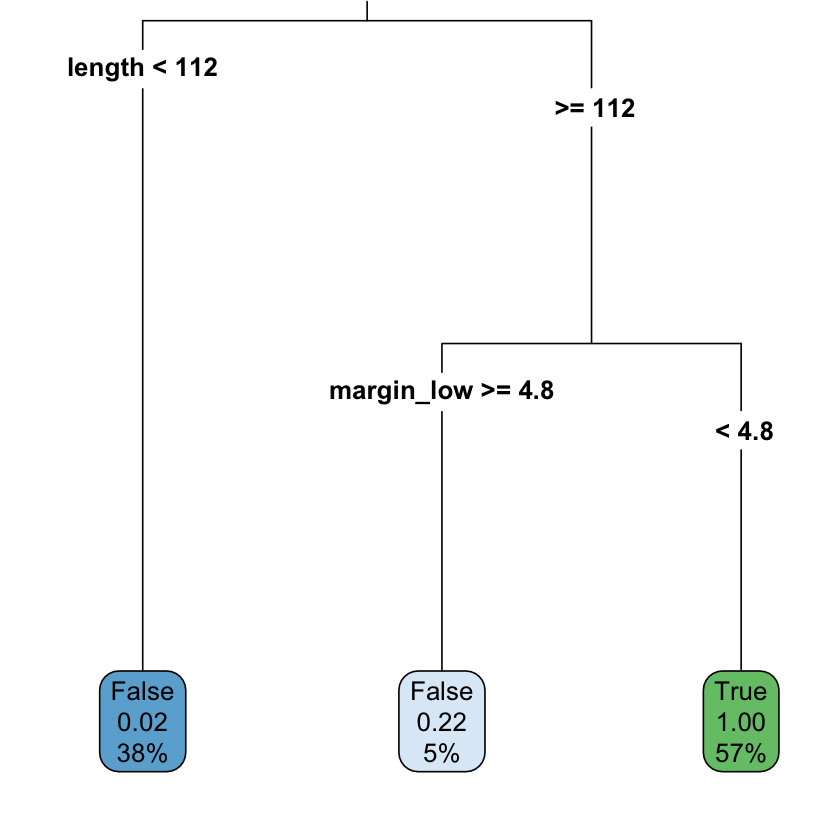

```r
# Save : Figure
png("figure/Figure 12 - Decision Tree.png", width = 16, height = 9, units = 'in', res = 300)
rpart.plot(dtree_fit$finalModel, type=3, fallen.leaves = TRUE, cex=1.3)
dev.off()

# Plot : Figure
rpart.plot(dtree_fit$finalModel, type=3, fallen.leaves = TRUE, cex=1.3)
```

### Reading the decision tree

According to the decision tree, a bill is true if:

- first, if its length is higher than or equal to 112 mm
- then, if its lower margin is lower than 4.8 mm.a

This decision tree confirms our observations made in Parts 1 and 2 where we said that the most distinguishing features of counterfeits were their lower margin and their length.

## 3. Logistic Regression

```r
bills <- transform(bills, is_genuine = as.character(is_genuine))

# 1 : real bills.
bills$is_genuine[bills$is_genuine=='True']<-1

# 0 : fale bills.
bills$is_genuine[bills$is_genuine=='False']<-0

bills <- transform(bills, is_genuine = as.numeric(is_genuine))

head(bills)
```

| is_genuine | diagonal | height_left | height_right | margin_low | margin_up | length |
| --- | --- | --- | --- | --- | --- | --- |
| 1 | 171.81 | 104.86 | 104.95 | 4.52 | 2.89 | 112.83 |
| 1 | 171.67 | 103.74 | 103.70 | 4.01 | 2.87 | 113.29 |
| 1 | 171.83 | 103.76 | 103.76 | 4.40 | 2.88 | 113.84 |
| 1 | 171.80 | 103.78 | 103.65 | 3.73 | 3.12 | 113.63 |
| 1 | 172.05 | 103.70 | 103.75 | 5.04 | 2.27 | 113.55 |
| 1 | 172.57 | 104.65 | 104.44 | 4.54 | 2.99 | 113.16 |

```r
# trainX : Contains the geometric variables that will be used to estimate is_genuine in the train dataset
trainX <- bills[, -1]
trainY <- bills$is_genuine

# The geometric variables present in billetsY will be used to estimate is_genuine.
m_lr <- train(trainX, trainY, method="glmStepAIC", direction = 'both', trControl=train.control)
print(m_lr)
print(m_lr$resample)
#print(summary(m_lr$finalModel))
```

[output not shown]

[output cut: 222 more lines]

```

No pre-processing
Resampling: Cross-Validated (5 fold)
Summary of sample sizes: 136, 136, 136, 136, 136
Resampling results:

  RMSE       Rsquared   MAE
  0.1755559  0.8788229  0.1379961

       RMSE  Rsquared       MAE Resample
1 0.1679119 0.8846697 0.1457480    Fold1
2 0.1477160 0.9231594 0.1205645    Fold2
3 0.1960706 0.8529226 0.1475754    Fold3
4 0.1902345 0.8547055 0.1422176    Fold4
5 0.1758463 0.8786571 0.1338749    Fold5
```

**How does the algorithm work?:** For each iteration, an ascending and descending stepwise method is applied. We start from a model that expresses the class of the note according to all the geometric variables. Then we add or remove variables until we get the linear combination of variables that minimizes the AIC (Akaike Information Criterion). This is a measure of the quality of the statistical model that depends on:

- the complexity of the model: k: the number of parameters used in the model
- the quality of the fit: L: the maximum of the model's likelihood function

### Modeling with logistic regression on the entire dataset

```r
m_lrs <- train(is_genuine ~ ., data = bills, method="glmStepAIC", trControl=trainControl("none"))
print(summary(m_lr$finalModel))
```

```
Start:  AIC=-109.49
.outcome ~ diagonal + height_left + height_right + margin_low +
    margin_up + length

               Df Deviance      AIC
- diagonal      1   4.7614 -111.354
- height_left   1   4.7935 -110.211
<none>              4.7576 -109.489
- height_right  1   4.8406 -108.551
- length        1   6.3665  -61.969
- margin_up     1   7.2413  -40.081
- margin_low    1   9.4446    5.079

Step:  AIC=-111.35
.outcome ~ height_left + height_right + margin_low + margin_up +
    length

               Df Deviance      AIC
- height_left   1   4.8087 -111.674
<none>              4.7614 -111.354
- height_right  1   4.8410 -110.537
- length        1   6.3666  -63.965
- margin_up     1   7.3457  -39.647
- margin_low    1  10.1586   15.468

Step:  AIC=-111.67
.outcome ~ height_right + margin_low + margin_up + length

               Df Deviance      AIC
- height_right  1   4.8433 -112.454
<none>              4.8087 -111.674
- length        1   6.3681  -65.925
- margin_up     1   7.3930  -40.555
- margin_low    1  10.2248   14.573

Step:  AIC=-112.45
.outcome ~ margin_low + margin_up + length

             Df Deviance      AIC
<none>            4.8433 -112.454
```

[output cut: 12 more lines]

```
             Estimate Std. Error t value Pr(>|t|)
(Intercept) -13.46443    2.68196  -5.020 1.32e-06 ***
margin_low   -0.38829    0.02508 -15.482  < 2e-16 ***
margin_up    -0.69062    0.06746 -10.237  < 2e-16 ***
length        0.16019    0.02205   7.263 1.39e-11 ***
---
Signif. codes:  0 ‘***’ 0.001 ‘**’ 0.01 ‘*’ 0.05 ‘.’ 0.1 ‘ ’ 1

(Dispersion parameter for gaussian family taken to be 0.02917674)

    Null deviance: 41.1765  on 169  degrees of freedom
Residual deviance:  4.8433  on 166  degrees of freedom
AIC: -112.45

Number of Fisher Scoring iterations: 2
```

## 4. Prediction

```r
bills_to_predict <- read.csv("data/test-billet.csv", header=TRUE, sep=",",na.strings=c(""))
```

```r
bills_to_predict
```

| diagonal | height_left | height_right | margin_low | margin_up | length | id |
| --- | --- | --- | --- | --- | --- | --- |
| 172.09 | 103.95 | 103.73 | 4.39 | 3.09 | 113.19 | B_1 |
| 171.52 | 104.17 | 104.03 | 5.27 | 3.16 | 111.82 | B_2 |
| 171.78 | 103.80 | 103.75 | 3.81 | 3.24 | 113.39 | B_3 |
| 172.02 | 104.08 | 103.99 | 5.57 | 3.30 | 111.10 | B_4 |
| 171.79 | 104.34 | 104.37 | 5.00 | 3.07 | 111.87 | B_5 |

For the prediction, now that the optimal model has been determined, I carry out a logistic regression on all the data, with the logit parameter so that the probabilities are between 0 and 1. Our program will be able to make a prediction on a bill, that is to say to determine if it is a real or a fake bill. For each bill, the classification algorithm will give the probability that the bill is true. If this probability is greater than or equal to 0.5, the bill will be considered true. Otherwise, it will be considered as a fake.

```r
model <- glm(is_genuine ~ margin_low + margin_up + length, data = bills, family=binomial(link="logit"))
```

```r
# Grâce au modèle établit, on prédit la réalité ou non des billets
fitted.results <- predict(model,newdata=bills_to_predict,type='response')
print("Probability that the bill are true :")
print(fitted.results)
```

```
[1] "Probability that the bill are true :"
           1            2            3            4            5
1.000000e+00 2.220446e-16 1.000000e+00 2.220446e-16 2.220446e-16
```

```r
fitted.results <- ifelse(fitted.results > 0.5,1,0)
fitted.results[fitted.results==1] <- 'True'
fitted.results[fitted.results==0] <- 'False'

# is_genuine is added to the dataframe bills_to_predict
bills_to_predict$is_genuine <- fitted.results
bills_to_predict <- transform(bills_to_predict, is_genuine = as.factor(is_genuine))

bills_to_predict
```

| diagonal | height_left | height_right | margin_low | margin_up | length | id | is_genuine |
| --- | --- | --- | --- | --- | --- | --- | --- |
| 172.09 | 103.95 | 103.73 | 4.39 | 3.09 | 113.19 | B_1 | True |
| 171.52 | 104.17 | 104.03 | 5.27 | 3.16 | 111.82 | B_2 | False |
| 171.78 | 103.80 | 103.75 | 3.81 | 3.24 | 113.39 | B_3 | True |
| 172.02 | 104.08 | 103.99 | 5.57 | 3.30 | 111.10 | B_4 | False |
| 171.79 | 104.34 | 104.37 | 5.00 | 3.07 | 111.87 | B_5 | False |

```r
# An id column (format: factor) is created.
bills$id <- rownames(bills)
bills <- transform(bills, id = as.factor(id))

# We collect the real bills and bills to predict in the same table.
data <- merge(bills, bills_to_predict, all = T, sort = FALSE)
rownames(data) <- data$id
dim(data)
```

1. 175

2. 8

```r
res.pca <- PCA(data[,c(1:7)], quali.sup = 1, ind.sup = 171:175, scale.unit = TRUE, graph=FALSE)
```

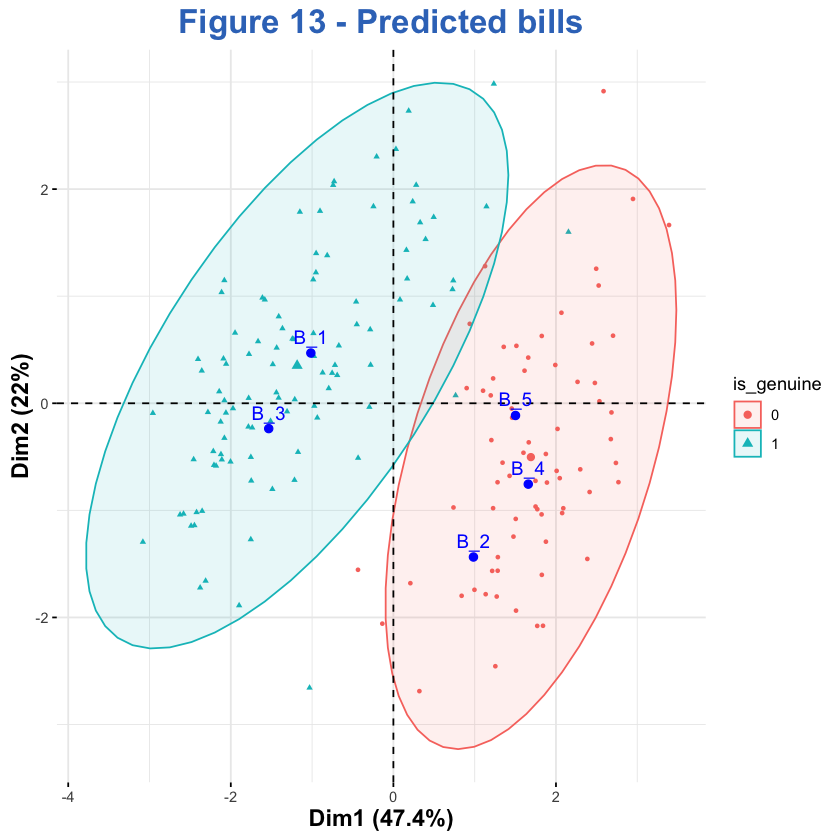

```r
# The bills to be predicted are displayed on the factorial plane
p <- fviz_pca_ind(res.pca, geom.ind = "point",pointsize = 1,habillage=1,addEllipses = TRUE)
p <- fviz_add(p, res.pca$ind.sup$coord) + labs(title = "Figure 13 - Predicted bills") + theme(plot.title = element_text(color="#3876C2", size=20, face="bold",hjust = 0.5),axis.title.x = element_text(color="black", size=14, face="bold",hjust = 0.5),axis.title.y = element_text(color="black", size=14, face="bold",vjust = 0.5)) + ggsave("figure/figure13_predicted_bills.png", width = 16, height = 9)
p
```